# Replication of GoDMC results in Generation Scotland

## Variance explained

Using an independent replication allows unbiased estimate of phenotypic variance explained

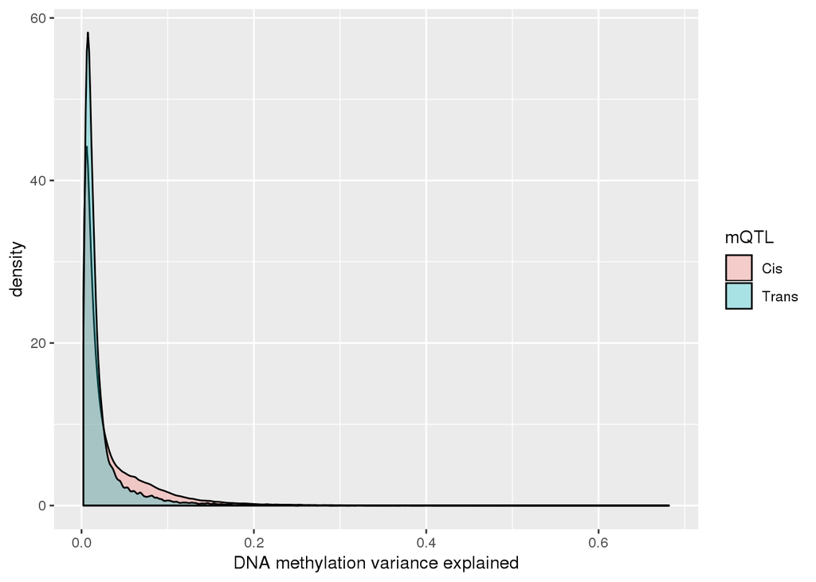

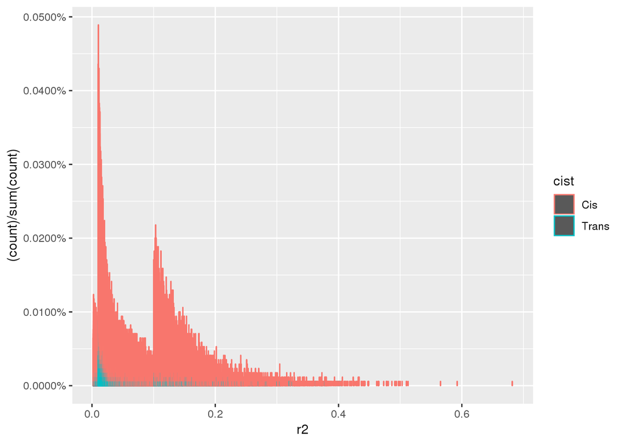

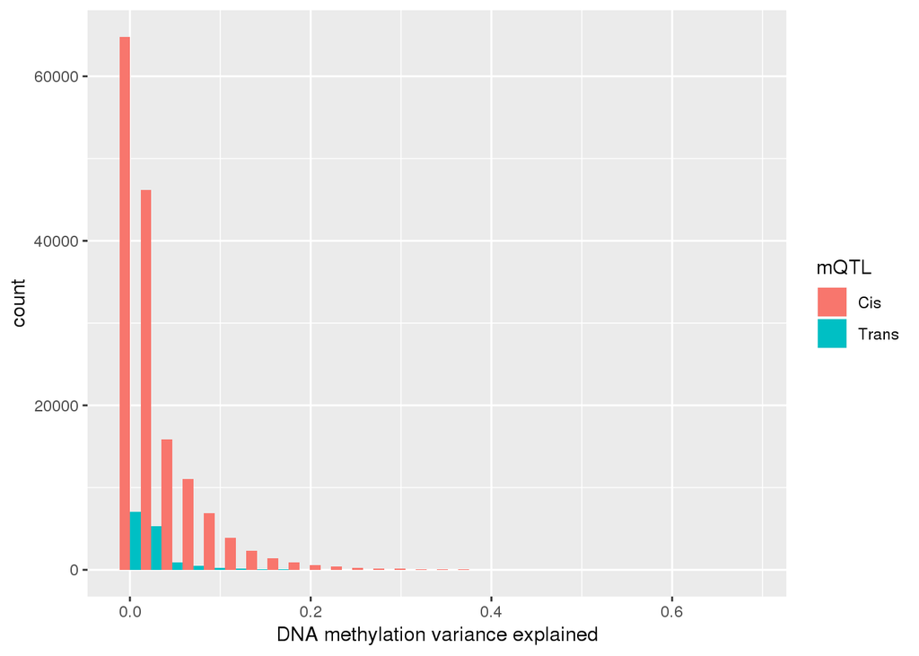

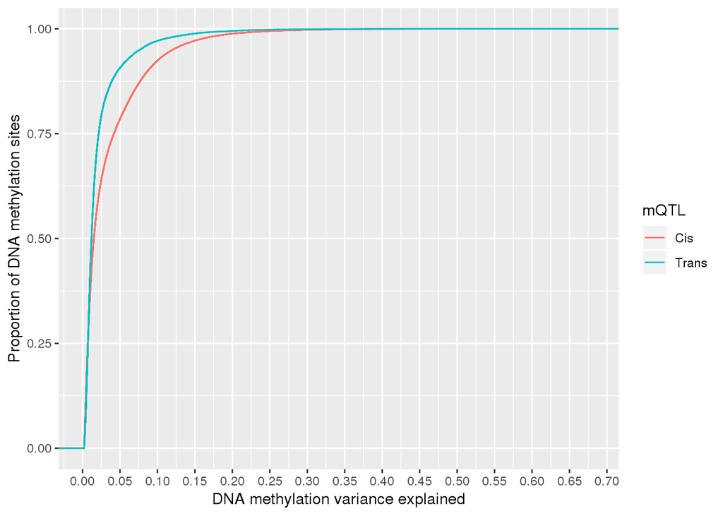

The cumulative plot shows variance explained in various percentages of DNA methylation sites. 99 % of the cis associations explain less than 0.2094 and 99% of the trans associations explain less than 0.1552 of the variance.

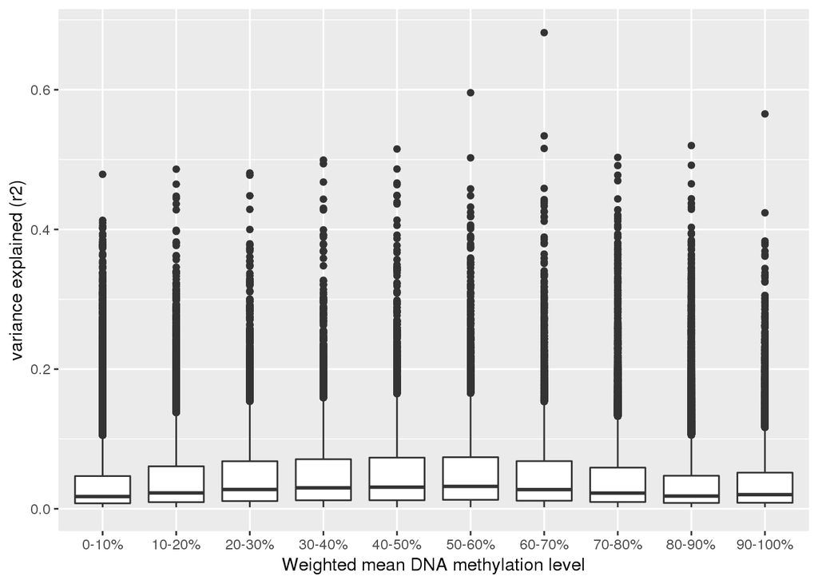

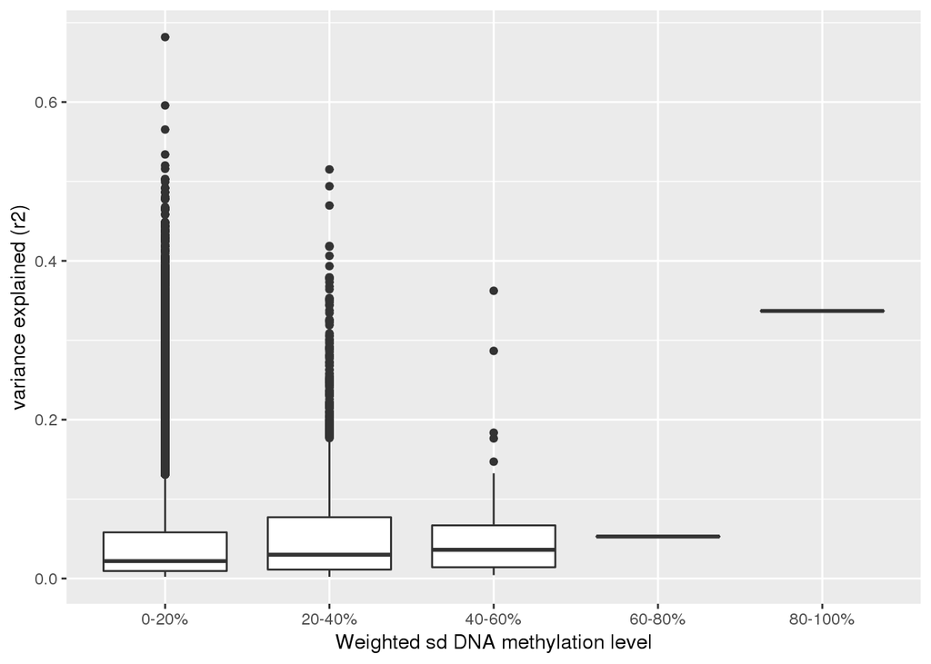

```
##                  Estimate   Std. Error    t value   Pr(>|t|)
## (Intercept)  0.0432523102 0.0002705994 159.838885 0.00000000
## meancpg     -0.0008990671 0.0004501923  -1.997073 0.04581932
```

```
##               Estimate   Std. Error   t value     Pr(>|t|)
## (Intercept) 0.03752167 0.0003397413 110.44191 0.000000e+00
## sdcpg       0.44054695 0.0257561497  17.10453 1.624891e-65
```

This plot shows that sites with intermediate methylation have larger r2

We previously calculated (with low precision) the SNP h2 of each CpG

```
## # A tibble: 2 x 3
##   what       m       mf
##   <chr>  <dbl>    <dbl>
## 1 hsq1  0.0418 0.0123
## 2 hsq2  0.0254 0.000737
```

```
## # A tibble: 1 x 2
##        m     mf
##    <dbl>  <dbl>
## 1 0.0428 0.0130
```

How does the SNP h2 (estimated in ARIES) relate to the variance explained by clumped SNPs (Generation Scotland)

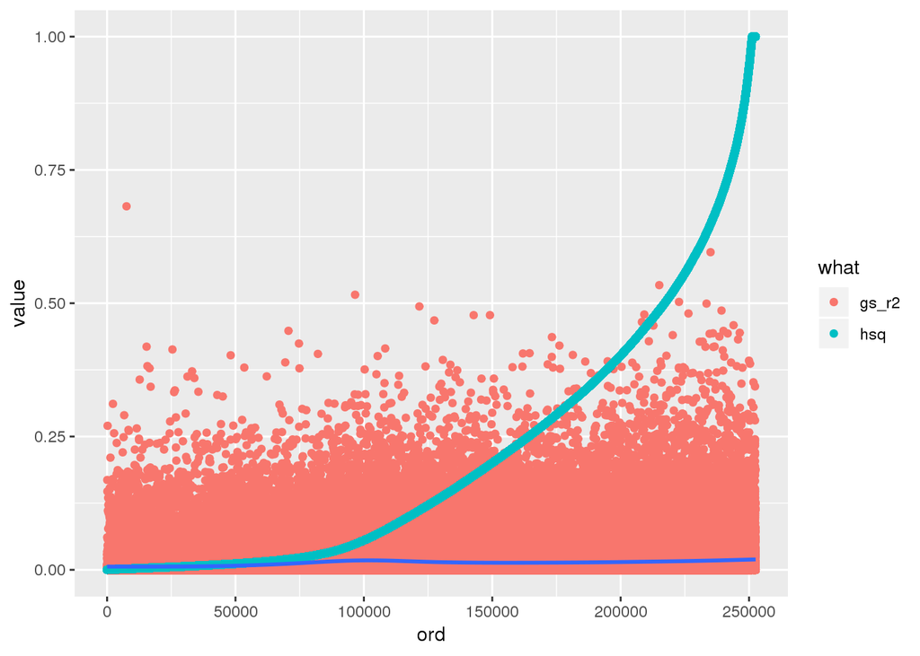

Use Van Dongen heritability estimates using twins

- There are 411169 CpGs with significant h2 estimates in van Dongen.
- 118955 were present in the GS replication dataset

What proportion of the h2 is explained by mQTLs?

```
## # A tibble: 117,028 x 30
##    cpg        r2 what    rMZ   rDZ h2_twinAE Pval_A_AE Pval_A_AE_adj
##    <chr>   <dbl> <chr> <dbl> <dbl>     <dbl>     <dbl>         <dbl>
##  1 cg00… 0.0116  hsqt…  0.37  0.15     0.36   0.         0
##  2 cg00… 0.00939 hsqt…  0.13  0.03     0.12   2.29e- 4   1
##  3 cg00… 0.0134  hsqt…  0.33  0.07     0.31   0.         0
##  4 cg00… 0.00414 hsqt…  0.3   0.07     0.290  0.         0
##  5 cg00… 0.0868  hsqt…  0.5   0.22     0.49   0.         0
##  6 cg00… 0.00744 hsqt…  0.27  0.01     0.26   2.03e-12   0.000000836
##  7 cg00… 0.123   hsqt…  0.81  0.39     0.81   0.         0
##  8 cg00… 0.0146  hsqt…  0.31  0.12     0.3    0.         0
##  9 cg00… 0.0162  hsqt…  0.34  0.2      0.34   0.         0
## 10 cg00… 0.00467 hsqt…  0.22  0.12     0.22   4.58e-11   0.0000188
## # ... with 117,018 more rows, and 22 more variables: c2_twinACE <dbl>,
## #   Pval_C_ACE <dbl>, Pval_C_ACE_adj <dbl>, d2_twinADE <dbl>,
## #   Pval_D_ADE <dbl>, Pval_D_ADE_adj <dbl>, h2_total <dbl>, h2_SNPs <dbl>,
## #   Pval_age_Ve <dbl>, Pval_age_Ve_adj <dbl>, Pval_age_Va <dbl>,
## #   Pval_age_Va_adj <dbl>, Pval_sex_Va <dbl>, Pval_sex_Va_adj <dbl>,
## #   Pval_sex_Ve <dbl>, Pval_sex_Ve_adj <dbl>, X <lgl>, Column.name <fct>,
## #   explanation <fct>, cohort <fct>, covariates <fct>, ord <dbl>
```

The mean h2 is 0.3605426 across 118955 sites. Correlation between variance explained in GoDMC and h2_twin incl h2==0: 0.3665047 Correlation between variance explained in GoDMC and h2_twin incl h2!=0: 0.3699778

```
##               Estimate   Std. Error   t value Pr(>|t|)
## (Intercept) 0.01239066 0.0002609058  47.49094        0
## h2_twinAE   0.08365930 0.0006157781 135.85948        0
```

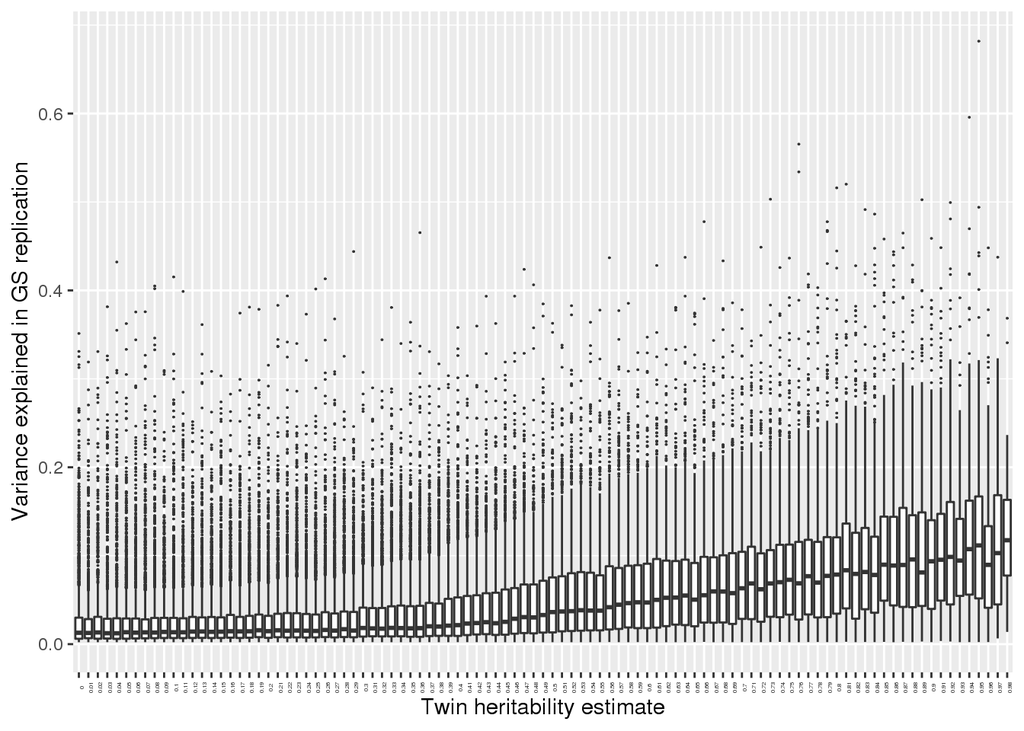

What proportion of h2 is explained? To summarise this set probes with h2==0 to h2==1e-10 because this gives division errors. r2 for probes with h2==0 are set to 0.

- There are 1927 CpGs with h2==0.

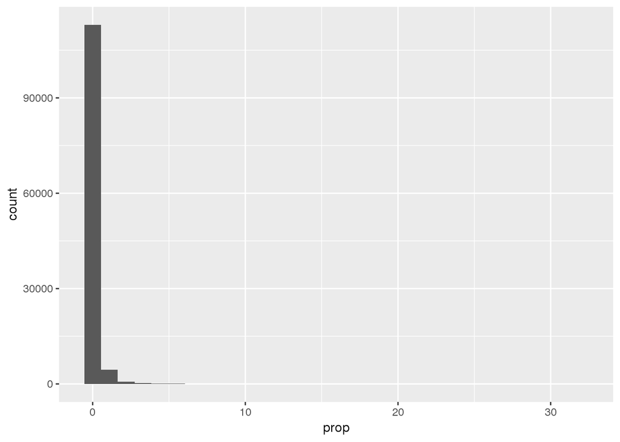

There are 2717 proportions above 1. These will be set to 1.

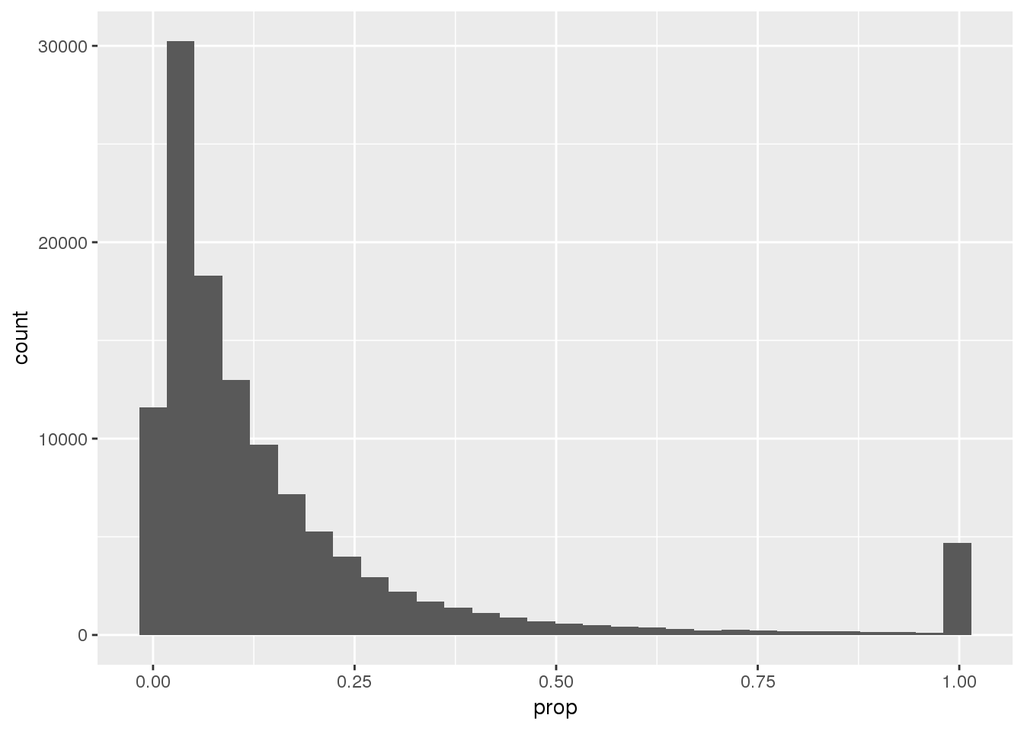

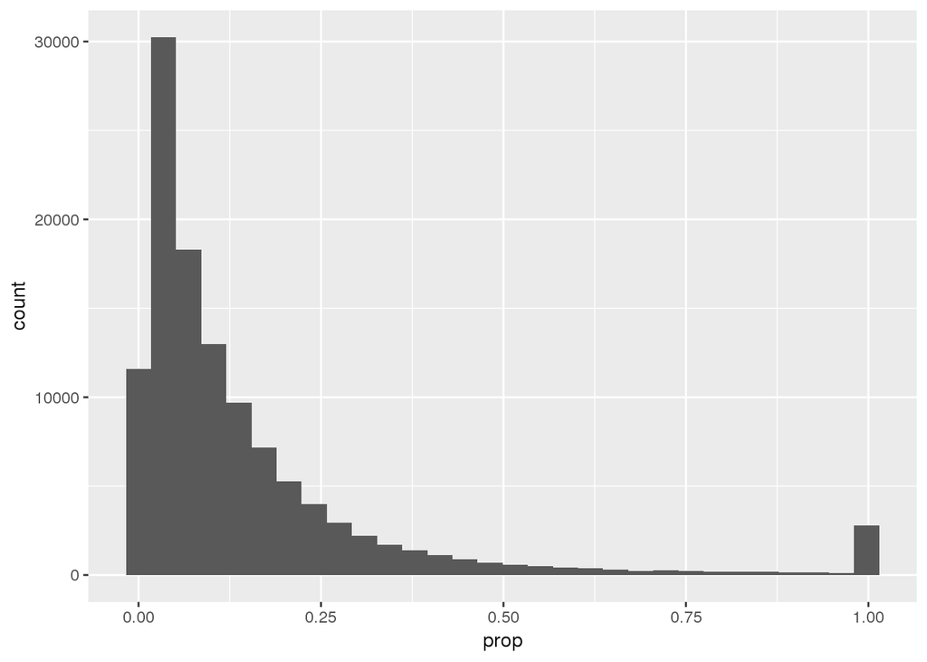

What proportion of h2 is explained? h2==0 has been replaced with 1e-10

| key | mean | median |
| --- | --- | --- |
| h2_twinAE | 0.3605426 | 0.340000 |
| prop | 0.1638636 | 0.084540 |
| r2 | 0.0425534 | 0.021936 |

What proportion of h2 is explained? h2==0 has been removed

| key | mean | median |
| --- | --- | --- |
| h2_twinAE | 0.3664793 | 0.3400000 |
| prop | 0.1500956 | 0.0824475 |
| r2 | 0.0427713 | 0.0221565 |

Do the same with McRae pedigree-based h2 estimates

- There are 417069 CpGs with significant h2 estimates in McRae.
- 121582 were present in the GS replication dataset

What proportion of the h2 is explained by mQTLs?

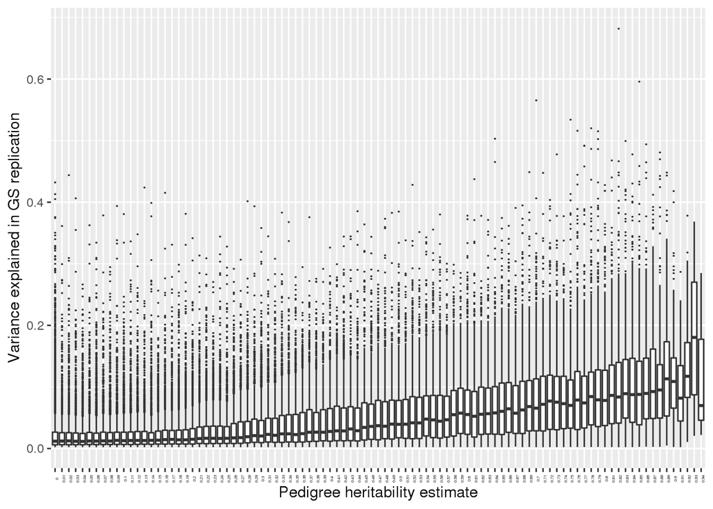

```
##               Estimate   Std. Error   t value Pr(>|t|)
## (Intercept) 0.01334562 0.0002268165  58.83886        0
## h2_cc       0.08982715 0.0005693626 157.76792        0
```

The mean h2 is 0.3236839 across 121582 sites. Correlation between variance explained in GoDMC and h2_pedigree: 0.4122335 Correlation between variance explained in GoDMC and h2_pedigree: 0.420792

What proportion of h2 is explained? To summarise this probes with h2==0 are replaced with h2==1e-10 to avoid division errors.

- There are 6451 CpGs with h2==0.

There are 3396 proportions above 1. These will be set to 1.

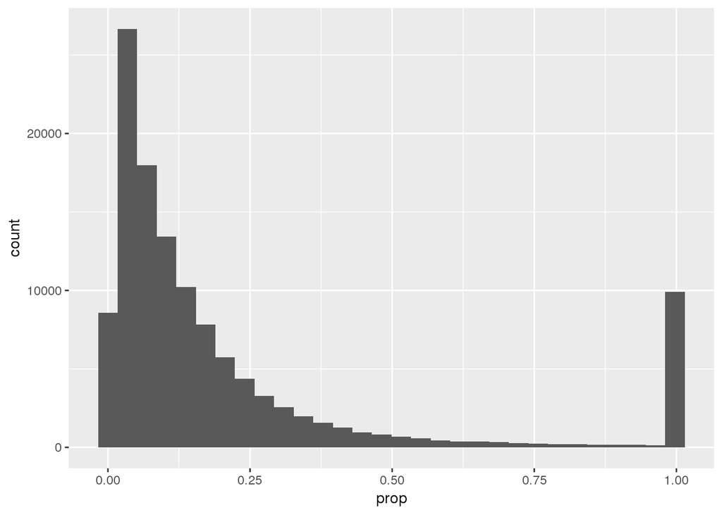

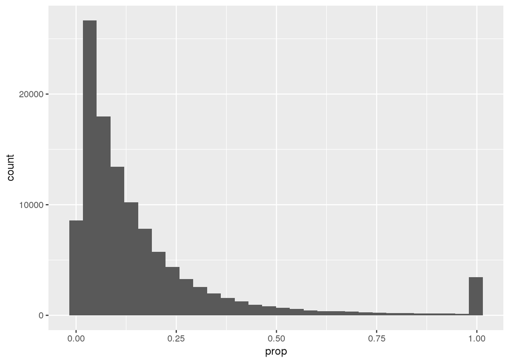

| key | mean | median |
| --- | --- | --- |
| h2_cc | 0.3236839 | 0.2820000 |
| prop | 0.2114937 | 0.1042117 |
| r2 | 0.0424212 | 0.0218900 |

| key | mean | median |
| --- | --- | --- |
| h2_cc | 0.3418205 | 0.3000000 |
| prop | 0.1673123 | 0.0962462 |
| r2 | 0.0432738 | 0.0227830 |

## Visualise proportion variance explained

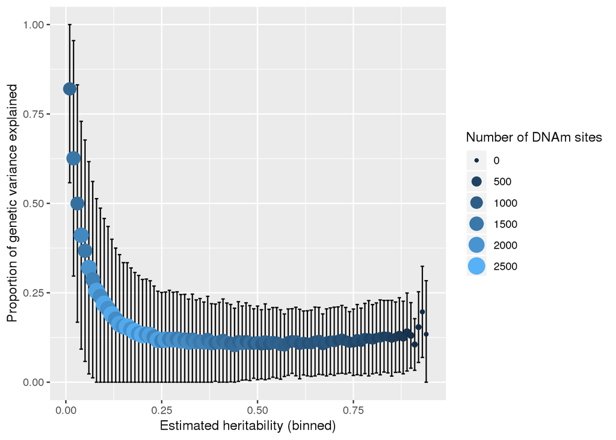

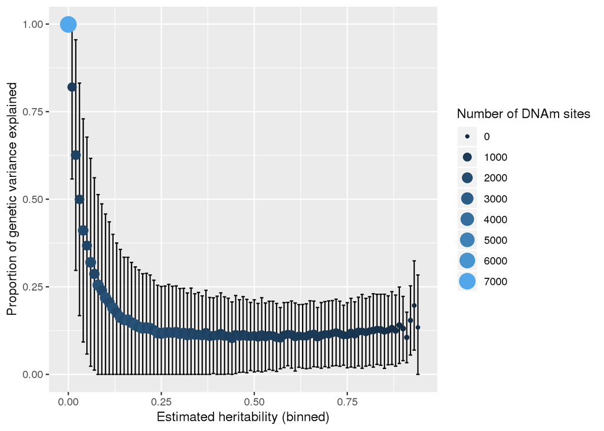

## Create tables

```
## [1] 417069
```

```
## [1] 411169
```

```
## [1] 440989
```

```
## [1] 403861
```

```
## [1] 403353
```

```
## [1] 277428
```

```
## [1] 115263
```

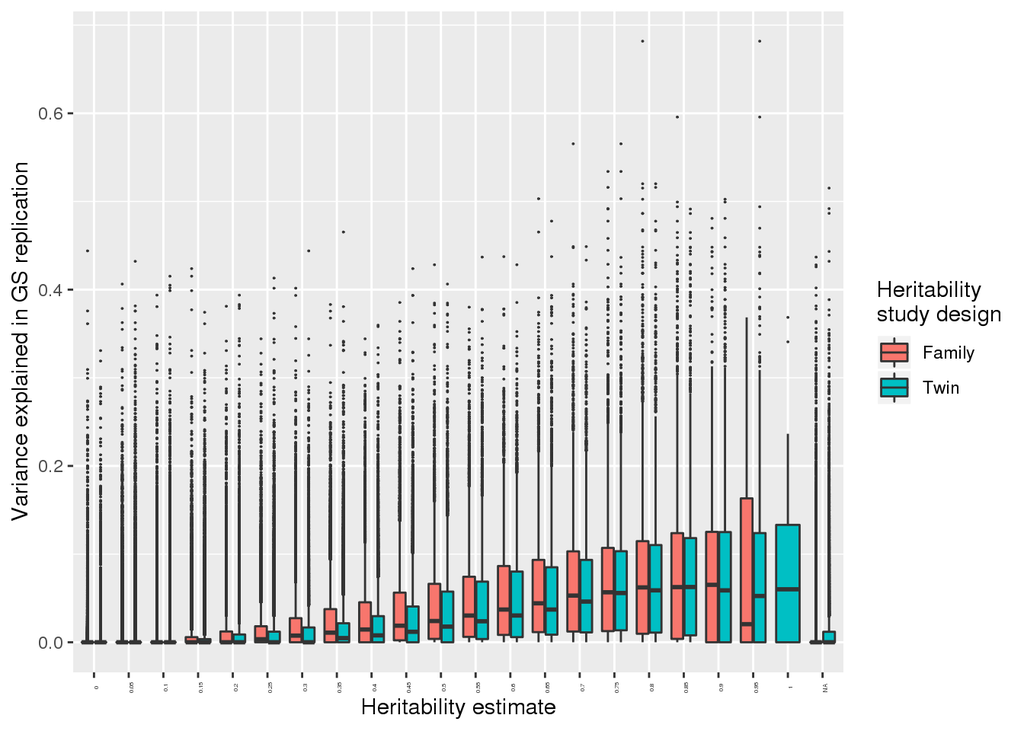

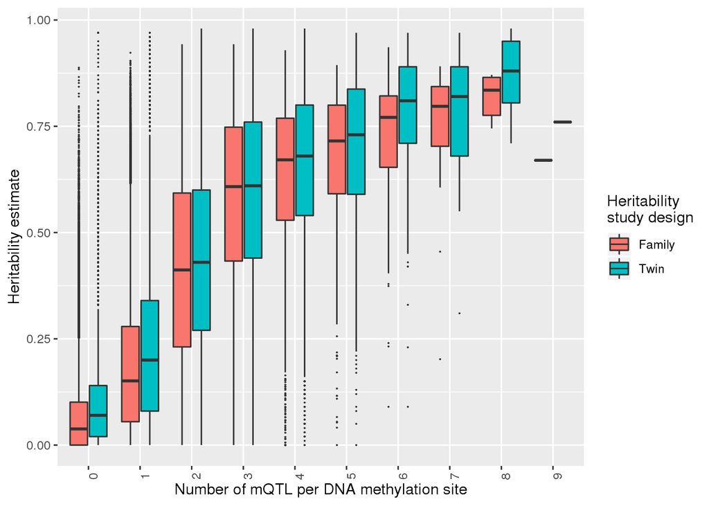

regression of mqtls~h2_McRae

```
##             Estimate  Std. Error  t value Pr(>|t|)
## (Intercept) 0.196716 0.001337318 147.0974        0
## value       2.960604 0.005076757 583.1683        0
```

correlation mqtls~h2_McRae

```
## # A tibble: 2 x 2
##   key      cor
##   <chr>  <dbl>
## 1 Family 0.686
## 2 Twin   0.661
```

```
##              Estimate   Std. Error  t value Pr(>|t|)
## (Intercept) 0.1627287 0.0003091318 526.4054        0
## r2          2.9072813 0.0084253518 345.0635        0
```

regression of h2_McRae~r2 using 403353 probes, missing r2 are set to 0 regression of h2_McRae~r2 using 403353 probes, missing r2 are set to 0

```
##              Estimate   Std. Error  t value Pr(>|t|)
## (Intercept) 0.1273274 0.0002958866 430.3252        0
## r2          3.1610582 0.0080792280 391.2575        0
```

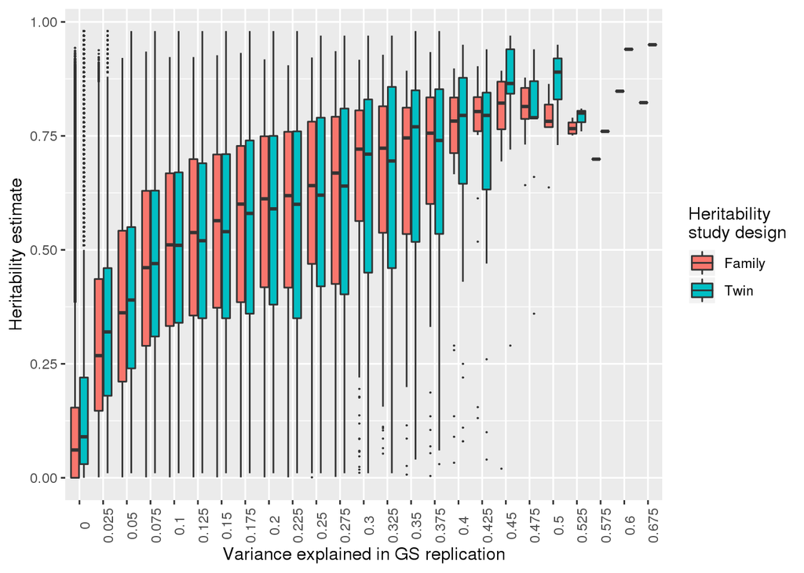